# Artificial Intelligence: Computer Assignment 5 - phase 1 - Neural Networks

> **Morteza Nouri, 810198481**

## Goals:

- Introduction to Feed Forward Neural Networks
- Effect of hyperparameters (e.g. learning rate, epochs and etc.) on network

## Description:

> In this project we are going to implement a nerual network which can recognize handwritten digits in Persian.

## Part 1: Preprocess

### 1.1: Data visualization

|  | data | label |
| --- | --- | --- |
| 0 | [[0, 0, 0, 0, 255, 255, 0, 0, 0, 0, 0, 0, 0, 0... | 6 |
| 1 | [[0, 0, 0, 0, 0, 0, 0, 0, 0, 0, 255, 255, 0, 0... | 5 |
| 2 | [[0, 255, 255, 255, 255, 255, 255, 255, 255, 0... | 0 |
| 3 | [[0, 0, 0, 0, 0, 0, 0, 0, 0, 0, 0, 0, 0, 0, 0,... | 2 |
| 4 | [[0, 0, 0, 0, 0, 0, 0, 0, 0, 0, 0, 0, 0, 0, 0,... | 7 |
| ... | ... | ... |
| 102347 | [[0, 0, 0, 0, 0, 255, 0, 0, 0, 0, 0, 0, 0, 0, ... | 6 |
| 102348 | [[0, 255, 0, 0, 0, 0], [255, 255, 255, 0, 0, 0... | 1 |
| 102349 | [[0, 0, 0, 0, 0, 255, 255, 255, 255, 0, 0, 0, ... | 0 |
| 102350 | [[0, 0, 0, 0, 0, 0, 0, 0, 0, 255, 255, 255, 25... | 8 |
| 102351 | [[0, 0, 0, 0, 0, 0, 0, 255, 255, 255, 255, 0, ... | 9 |

102352 rows × 2 columns

```
[[  0   0   0   0   0   0   0   0   0   0   0 255 255   0]
 [  0   0   0   0   0   0   0   0   0   0   0 255 255 255]
 [  0 255 255 255   0   0   0   0   0   0   0 255 255 255]
 [255 255 255 255 255   0   0   0   0   0   0 255 255 255]
 [255 255 255 255 255 255   0   0   0   0   0 255 255 255]
 [255 255 255 255 255 255   0   0   0   0   0 255 255 255]
 [255 255 255 255 255 255   0   0   0   0   0 255 255 255]
 [  0 255 255 255 255 255 255   0   0   0   0 255 255 255]
 [  0 255 255 255 255 255 255   0   0   0   0 255 255   0]
 [  0   0 255 255 255 255 255   0   0   0   0 255 255   0]
 [  0   0 255 255 255 255 255 255   0   0 255 255 255   0]
 [  0   0   0 255 255 255 255 255 255 255 255 255 255   0]
 [  0   0   0   0 255 255 255 255 255 255 255 255   0   0]
 [  0   0   0   0   0 255 255 255 255 255   0   0   0   0]
 [  0   0   0   0   0   0 255 255 255   0   0   0   0   0]
 [  0   0   0   0   0   0   0 255 255 255   0   0   0   0]
 [  0   0   0   0   0   0   0 255 255 255   0   0   0   0]
 [  0   0   0   0   0   0   0   0 255 255 255   0   0   0]
 [  0   0   0   0   0   0   0   0 255 255 255   0   0   0]
 [  0   0   0   0   0   0   0   0   0 255 255   0   0   0]
 [  0   0   0   0   0   0   0   0   0 255 255   0   0   0]
 [  0   0   0   0   0   0   0   0   0 255 255 255   0   0]
 [  0   0   0   0   0   0   0   0   0   0 255 255   0   0]
 [  0   0   0   0   0   0   0   0   0   0 255 255 255   0]
 [  0   0   0   0   0   0   0   0   0   0 255 255 255   0]
 [  0   0   0   0   0   0   0   0   0   0 255 255 255   0]
 [  0   0   0   0   0   0   0   0   0   0 255 255 255   0]
 [  0   0   0   0   0   0   0   0   0   0   0 255 255 255]
 [  0   0   0   0   0   0   0   0   0   0   0 255 255 255]
 [  0   0   0   0   0   0   0   0   0   0   0 255 255 255]
 [  0   0   0   0   0   0   0   0   0   0   0 255 255 255]
 [  0   0   0   0   0   0   0   0   0   0   0 255 255 255]
 [  0   0   0   0   0   0   0   0   0   0   0   0 255   0]]
Max pixel value: 255
Min pixel value: 0
```

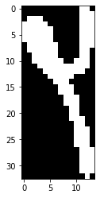

```
Image Shape: (33, 14)
```

```python
import pickle
import random
import pandas as pd
import numpy as np
import matplotlib.pyplot as plt

np.warnings.filterwarnings('ignore', category=np.VisibleDeprecationWarning)

pkl_file = open('dataset/data.pkl', 'rb')
data = pickle.load(pkl_file)

pkl_file = open('dataset/labels.pkl', 'rb')
labels = pickle.load(pkl_file)

df = pd.concat([pd.DataFrame(data, columns=['data']), pd.DataFrame(labels, columns=['label'])], axis=1)

display(df)

choice = random.randint(0, len(data))
print(df['data'][choice])
print(f"Max pixel value: {df['data'][choice].max()}")
print(f"Min pixel value: {df['data'][choice].min()}")
plt.imshow(df['data'][choice], cmap='Greys_r')
plt.show()
print(f"Image Shape: {df['data'][choice].shape}")
```

### 1.2: resizing the image data to the equal shapes.

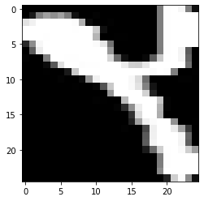

```
Image Shape: (25, 25)
```

```python
import cv2

def resize(img):
    return cv2.resize(img, (25, 25), interpolation=cv2.INTER_CUBIC)

df['data'] = df['data'].apply(resize)

plt.imshow(df['data'][choice], cmap='Greys_r')
plt.show()
print(f"Image Shape: {df['data'][choice].shape}")
```

### 1.3: Spliting the data to train and test

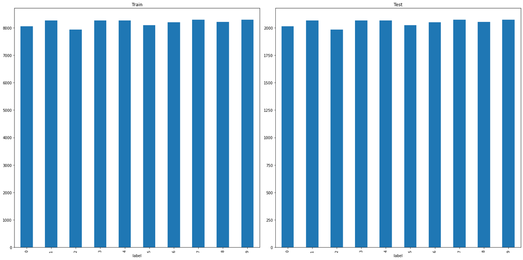

```python
from sklearn.model_selection import train_test_split

train, test = train_test_split(df, stratify=df['label'], test_size=0.2)

train = train.reset_index(drop=True)
test = test.reset_index(drop=True)

plt.figure(figsize=(20,10))

plt.subplot(1, 2, 1)
train.groupby('label').size().plot(kind='bar', title='Train')

plt.subplot(1, 2, 2)
test.groupby('label').size().plot(kind='bar', title='Test')

plt.tight_layout()
plt.show()
```

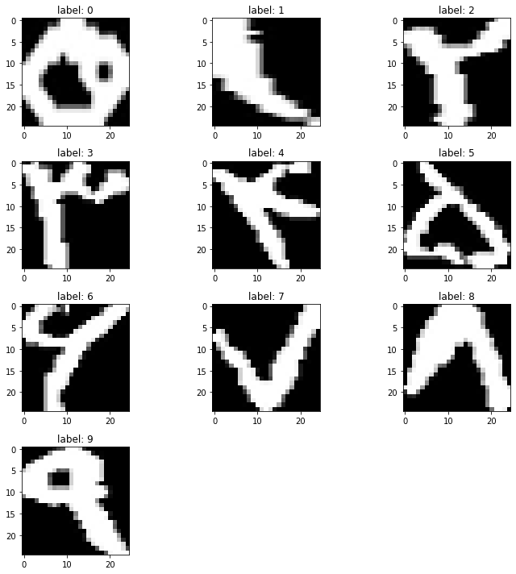

```python
plt.figure(figsize=(10,10))
i = 0
for label, row in train.groupby('label').first().iterrows():
    plt.subplot(4, 3, i + 1)
    plt.imshow(row['data'], cmap='Greys_r')
    plt.title(f'label: {label}')
    i += 1

plt.tight_layout()
plt.show()
```

### 1.4: Normalization

Normalizing the data generally speeds up learning and leads to faster convergence.Also, normalization ensures that the magnitude of the values that a feature assumes are more or less the same. At first when weights are initialized, those features with high mean will have the upper hand. Also, it is worth mentioning that by using big numbers(such as 255 or etc) we might reach exploiding gradiesnts sooner than expected!

```python
train['data'] = train['data'].div(255)
test['data'] = test['data'].div(255)

print(f"Max pixel value in Train: {train['data'][0].max()}")
print(f"Max pixel value in Test: {test['data'][0].max()}")
```

```
Max pixel value in Train: 1.0
Max pixel value in Test: 1.0
```

# Part 2: completing codes

# Dataloader

```python
class Dataloader:
    '''
    This class prepares the dataset for the neural network.
    '''

    def __init__(self, data, labels, n_classes, batch_size=None, shuffle=False):
        '''
        This is the constructor. It gets dataset information and initializes the
        Dataloader class fields.
            Parameters:
                data: features your dataset in pandas.Dataframe format.
                labels: labels of your dataset in pandas.Dataframe format.
                n_classes: number of classes you have in your dataset.
                batch_size: the number of samples that will be propagated through the network.
                shuffle: boolean value indicating whether or not the dataset should be shuffled
        '''

        assert len(data)==len(labels)
        self.__n_classes = n_classes
        self.__batch_size = batch_size
        self.__shuffle = shuffle
        self.__data = data
        self.__onehot_labels = self.__onehot(labels, self.__n_classes)

    def __onehot(self, labels, n_classes):
        '''
        This private method gets labels and provides one_hot vectors of labels.
        For categorical variables where no such ordinal relationship exists,
        the integer encoding is not enough.
        In this case, a one-hot encoding can be applied to the integer representation.
        This is where the integer encoded variable is removed, and a new binary variable is
        added for each unique integer value.
        example:
            red,    green,    blue
            1,      0,        0
            0,      1,        0
            0,      0,        1
                Parameters:
                        label: lables of your dataset in pandas.Dataframe format.
                        n_classes: number of classes you have in your dataset.

                Returns:
                    onehot_vectors: onehot vectors of the labels
        '''
        onehot_vectors = np.matrix(pd.get_dummies(labels))
        return onehot_vectors

    def __shuffle_dataset(self):
        '''
        This private method shuffles your dataset.
        It uses data and onehot_labels to shuffle them
        symmetrical.
        '''
        random_indices = np.random.permutation(len(self.__data))
        self.__data = self.__data[random_indices]
        self.__onehot_labels = self.__onehot_labels[random_indices]


    def __iter__(self):
        '''
        The __iter__() function returns an iterator for the
        given object (array, set, tuple, etc., or custom objects).
        This will return your dataset in the batch_size given. This should
        be used to provide data for the neural network.
        '''

        if self.__shuffle:
            self.__shuffle_dataset()

        if self.__batch_size==None:
            yield (np.matrix(self.__data), np.matrix(self.__onehot_labels))
            return

        for idx in range(0, len(self.__data), self.__batch_size):
            yield (np.matrix(self.__data[idx:idx+self.__batch_size]),
                   np.matrix(self.__onehot_labels[idx:idx+self.__batch_size]))
```

# Activation Functions

```python
class Identical:
    '''
    This is the Identical activation function. This activation function just
    return the value it gets.
    '''

    def __init__(self):
        '''
        This is the constructor. It does not have any fields
        as a result, there is no need to do anything in the constructor.
        '''
        pass

    def __val(self, matrix):
        '''
        This private method gets a matrix and uses the activity function on that.
        As this is an identical activity function, it just
        returns np.matrix of the input.

            Parameters:
                matrix: np.matrix of values
            Returns:
                identical_value: np.matrix of input with float datatypes
        '''
        identical_value = np.matrix(matrix, dtype=float)
        return identical_value

    def derivative(self, matrix):
        '''
        This method returns the derivation of the input.
        As the derivation of x is one, this method returns
        a matrix of one with the shape of the input matrix.

            Parameters:
                matrix: np.matrix of values
            Returns:
                identical_derivative: np.matrix of ones with matrix shape
        '''
        temp = np.matrix(matrix, dtype=float)
        identical_derivative = np.matrix(np.full(np.shape(temp), 1.))
        return identical_derivative

    def __call__(self, matrix):
        '''
        __call__ is a special function in Python that, when implemented inside a class,
        gives its instances (objects) the ability to behave like a function.
        Here we return the _value method output.

            Parameters:
                matrix: np.matrix of values
            Returns:
                __val(matrix): __val return value for the input matrix
        '''
        return self.__val(matrix)


class Relu:
    '''
    This is the Relu activation function.
    The rectified linear activation function or ReLU for short
    is a piecewise linear function that will output the input directly
    if it is positive, otherwise, it will output zero.
    '''

    def __init__(self):
        '''
        This is the constructor. It does not have any fields
        as a result, there is no need to do anything in the constructor.
        '''
        pass

    def __val(self, matrix):
        '''
        This private method gets a matrix and uses the activity function on that.
        It will set 0 in the matrix if the value is less than 0 else, it returns the value itself.

            Parameters:
                matrix: np.matrix of values
            Returns:
                relu_value: np.matrix of relu activation function result
        '''
        relu_value = np.matrix(matrix, dtype=float)
        relu_value[relu_value < 0] = 0
        return relu_value

    def derivative(self, matrix):
        '''
        Returns the derivation value of relu function on input matrix.

            Parameters:
                matrix: np.matrix of values
            Returns:
                relu_derivative: np.matrix of relu activation function derivation result
        '''
        relu_derivative = np.matrix(matrix, dtype=float)
        relu_derivative[relu_derivative > 0] = 1.
        relu_derivative[relu_derivative < 0] = 0.
        return relu_derivative

    def __call__(self, matrix):
        '''
        __call__ is a special function in Python that, when implemented inside a class,
        gives its instances (objects) the ability to behave like a function.
        Here we return the _relu method output.

            Parameters:
                matrix: np.matrix of values
            Returns:
                __relu(matrix): __relu return value for the input matrix
        '''
        return self.__val(matrix)


class LeakyRelu:
    '''
    This is the Leaky Relu activation function.
    Leaky Rectified Linear Unit, or Leaky ReLU,
    is a type of activation function based on a ReLU,
    but it has a small slope for negative values instead
    of a flat slope.
    '''

    def __init__(self, negative_slope=0.01):
        '''
        This is the constructor.
        It sets negative_slope field.
            Parameters:
                negative_slope: slope for negative input values
        '''
        self.negative_slope = 0.01

    def __val(self, matrix):
        '''
        This private method gets a matrix and uses the activity function on that.
        It will set negative_slope*value in the matrix if the value is less than 0, else it
        returns the value itself.

            Parameters:
                matrix: np.matrix of values
            Returns:
                relu_value: np.matrix of relu activation function result
        '''
        leacky_relu_value = np.maximum(self.negative_slope * matrix, matrix)
        return leacky_relu_value

    def derivative(self, matrix):
        '''
        Returns the derivation value of leaky relu function on input matrix.

            Parameters:
                matrix: np.matrix of values
            Returns:
                leacky_relu_derivative: np.matrix of leaky relu activation function derivation result
        '''
        temp = np.matrix(matrix, dtype=float)
        leacky_relu_derivative = np.ones_like(temp)
        leacky_relu_derivative[temp <= 0] = self.negative_slope
        return leacky_relu_derivative

    def __call__(self, matrix):
        '''
        __call__ is a special function in Python that, when implemented inside a class,
        gives its instances (objects) the ability to behave like a function.
        Here we return the _val method output.

            Parameters:
                matrix: np.matrix of values
            Returns:
                __val(matrix): __val return value for the input matrix
        '''
        return self.__val(matrix)


class Sigmoid:
    '''
    A sigmoid function is a mathematical function having a
    characteristic "S"-shaped curve or sigmoid curve.
    It return S(x)=1/(1+e^-x)
    '''

    def __init__(self): pass

    def __val(self, matrix):
        '''
        Returns 1/(1+e^-x) of values

            Parameters:
                matrix: np.matrix of values
            Returns:
                sigmoid_value: np.matrix of relu activation function result
        '''
        temp = np.matrix(matrix, dtype=float)
        sigmoid_value = 1/(1 + np.exp(-temp))
        return sigmoid_value

    def derivative(self, matrix):
        '''
        Returns the derivation value of sigmoid function on input matrix.

            Parameters:
                matrix: np.matrix of values
            Returns:
                sigmoid_derivative: np.matrix of sigmoid activation function derivation result
        '''
        sigmoid_derivative = np.multiply(self.__val(matrix), (1. - self.__val(matrix)))
        return sigmoid_derivative

    def __call__(self, matrix):
        '''
        __call__ is a special function in Python that, when implemented inside a class,
        gives its instances (objects) the ability to behave like a function.
        Here we return the _val method output.

            Parameters:
                matrix: np.matrix of values
            Returns:
                __val(matrix): __val return value for the input matrix
        '''
        return self.__val(matrix)


class Softmax:
    '''
    The softmax function, also known as softargmax  or normalized
    exponential function is a generalization of the logistic
    function to multiple dimensions. It is used in multinomial logistic
    regression and is often used as the last activation function of a neural
    network to normalize the output of a network to a probability distribution
    over predicted output classes, based on Luce's choice axiom.
    Softmax return (e^x_i / (Σe^x_j for j = 1, ..., J))
    '''

    def __init__(self):
        '''
        This is the constructor. It does not have any fields
        as a result, there is no need to do anything in the constructor.
        '''
        pass

    def __val(self, matrix):
        '''
        This private method gets a matrix and uses the softmax on that.
        Softmax return (e^x_i / (Σe^x_j for j = 1, ..., J))

            Parameters:
                matrix: np.matrix of values
            Returns:
                relu_value: np.matrix of relu activation function result
        '''
        temp = np.matrix(matrix, dtype=float)
        softmax_value = np.exp(temp - np.max(temp))
        softmax_value /= softmax_value.sum(axis=1)
        return softmax_value


    def __call__(self, matrix):
        '''
        __call__ is a special function in Python that, when implemented inside a class,
        gives its instances (objects) the ability to behave like a function.
        Here we return the _val method output.

            Parameters:
                matrix: np.matrix of values
            Returns:
                __val(matrix): __val return value for the input matrix
        '''
        return self.__val(matrix)

class Tanh:

    def __init__(self):
      '''
      This is the constructor. It does not have any fields
      as a result, there is no need to do anything in the constructor.
      '''
      pass

    def __val(self, matrix):
        '''
        This private method gets a matrix and uses the activity function on that.
        It performs Tanh on the values.

            Parameters:
                matrix: np.matrix of values
            Returns:
                tanh_value: np.matrix of Tanh activation function result
        '''
        temp = np.matrix(matrix, dtype=float)
        tanh_value = np.matrix((np.exp(temp) - np.exp(-temp)) / (np.exp(temp) + np.exp(-temp)))
        return tanh_value

    def derivative(self, matrix):
        '''
        Returns the derivation value of Tanh function on input matrix.

            Parameters:
                matrix: np.matrix of values
            Returns:
                sigmoid_derivative: np.matrix of Tanh activation function derivation result
        '''
        tanh_derivative = 1 - np.power(self.__val(matrix), 2)
        return tanh_derivative

    def __call__(self, matrix):
        '''
        __call__ is a special function in Python that, when implemented inside a class,
        gives its instances (objects) the ability to behave like a function.
        Here we return the _val method output.

            Parameters:
                matrix: np.matrix of values
            Returns:
                __val(matrix): __val return value for the input matrix
        '''
        return self.__val(matrix)
```


# Loss Function

```python
class CrossEntropy: #(with softmax)
    '''
    Cross-entropy is a measure of the difference between two probability
    distributions for a given random variable or set of events. You might
    recall that information quantifies the number of bits required to encode
    and transmit an event.
    The above image can help you.
    '''

    def __init__(self):
        '''
        This is the constructor. It does not have any fields
        as a result, there is no need to do anything in the constructor.
        '''
        pass

    def __val(self, true_val, expected_val):
        '''
        L(y^, y) = - Σ (y^(k)log (y^)^(k)) for k in K
        Parameters:
            true_val: calculated values (generated by neural network)
            expected_val: real values in dataset
        Returns:
            cross_entropy_value: cross entropy of inputs
        '''
        assert np.shape(true_val)==np.shape(expected_val)
        softmax = Softmax()
        cross_entropy_value = np.sum(-np.multiply(np.matrix(expected_val, dtype=float), np.log(softmax(true_val))), axis=1)
        return cross_entropy_value

    def derivative(self, true_val, expected_val):
        '''
        Returns derivation of cross entropy.
            Parameters:
                true_val: calculated values (generated by neural network)
                expected_val: real values in dataset
            Returns:
                cross_entropy_derivative: cross entropy derivation of inputs
        '''
        assert np.shape(true_val)==np.shape(expected_val)
        softmax = Softmax()
        cross_entropy_derivative = softmax(true_val) - expected_val
        return cross_entropy_derivative

    def __call__(self, true_val, expected_val):
        '''
        __call__ is a special function in Python that, when implemented inside a class,
        gives its instances (objects) the ability to behave like a function.
        Here we return the _val method output.

            Parameters:
                true_val: calculated values (generated by neural network)
                expected_val: real values in dataset
            Returns:
                __val(matrix): __val return value for the input matrix
        '''
        return self.__val(true_val, expected_val)
```

# Layer

```python
class Layer:
    '''
    The layer class is used to define neural network layers.
    It stores all needed information for each layer, such as neurons count,
    weight matrix, bias, the output after applying the activation function, etc.
    '''

    DEFAULT_LOW, DEFAULT_HIGH, DEFAULT_MEAN, DEFAULT_VAR = 0, 0.05, 0., 1.

    def __init__(self, input_size, output_size, activation=Identical(), initial_weight='uniform',
                 **initializing_parameters):
        '''
        Parameters:
            input_size: the size of the input of this layer.
            output_size: the size of the output after this layer.
            activation: the activation function. It can be initialized to either of the previously defined activation classes.
                               default is an Identical activation function.
            initial_weight: either normal or uniform. It defines the method for weight initialization.
        '''

        assert type(initial_weight)==str, 'Undefined activation function!'

        self.__weight_initializer_dict = {'uniform':self.__uniform_weight, 'normal':self.__normal_weight}

        assert initial_weight in self.__weight_initializer_dict, 'Undefined weight initialization function!'


        self.__n_neurons = output_size
        weight_initializer = self.__weight_initializer_dict[initial_weight]
        self.__weight = weight_initializer(input_size, self.__n_neurons, **initializing_parameters)
        self.__bias = weight_initializer(1, self.__n_neurons, **initializing_parameters)
        self.__activation = activation

        self.__last_input = None
        self.__last_activation_input = None
        self.__last_activation_output = None
        self.__last_activation_derivative = None

    def forward(self, layer_input):
        '''
        It calculates the output of this layer for the layer_input argument.
        This method also stores __last_input, __last_activation_input, and __last_activation_derivative
        for future use in backpropagation.
        Parameters:
            layer_input: 2d np.matrix representing the input matrix of this layer.
        Returns:
            Final output of this layer after applying the activation function.
        '''
        assert np.ndim(layer_input)==2
        assert np.size(self.__weight,0) == np.size(layer_input,1)
        self.__last_input = layer_input
        self.__last_activation_input = np.add(np.dot(self.__last_input, self.__weight), self.__bias)
        self.__last_activation_output = self.__activation(self.__last_activation_input)
        self.__last_activation_derivative = self.__activation.derivative(self.__last_activation_output)
        return self.__last_activation_output

    def update_weights(self, backprop_tensor, lr):
        '''
        It updates Layer weights according to the backpropagation matrix and learning rate.
        This method updates bias values as well.
        Parameters:
            backprop_tensor: 2d np.matrix passed from the next layer containing gradient values.
            lr: learning rate
        Returns:
            backprop_tensor to be used by the previous layer.
        '''
        assert np.ndim(backprop_tensor)==2
        assert np.size(backprop_tensor,0) == np.size(self.__last_activation_derivative,0)
        assert np.size(backprop_tensor,1) == self.__n_neurons
        backprop_tensor = np.multiply(backprop_tensor, self.__last_activation_derivative)
        self.__weight -= (lr * np.dot(self.__last_input.T, backprop_tensor))
        self.__bias -= (lr * np.dot(np.ones((1, backprop_tensor.shape[0])), backprop_tensor))
        backprop_tensor = np.dot(backprop_tensor, self.__weight.T)
        return backprop_tensor

    def __uniform_weight(self, dim1, dim2, **initializing_parameters):
        '''
        Initializes weights as a uniform distribution between low and high values.
        It uses default low and high values unless low or high are passed in initializing_parameters.
        Parameters:
            dim1: the size of the first dimension of weights.
            dim2: the size of the second dimension of weights.
            initializing_parameters: other initializing parameters; it can include custom low or high values.
        Returns:
            np.matrix with size (dim1, dim2) initialized using uniformly distributed values.
        '''
        low, high = self.DEFAULT_LOW, self.DEFAULT_HIGH
        if 'low' in initializing_parameters.keys(): low = initializing_parameters['low']
        if 'high' in initializing_parameters.keys(): high = initializing_parameters['high']
        weights = np.random.uniform(low, high=high, size=(dim1, dim2))
        return weights

    def __normal_weight(self, dim1, dim2, **initializing_parameters):
        '''
        Initializes weights as a normal distribution with mean and var values.
        It uses default mean and variance values unless mean or var are passed in initializing_parameters.
        Parameters:
            dim1: the size of the first dimension of weights.
            dim2: the size of the second dimension of weights.
            initializing_parameters: other initializing parameters; it can include custom mean or var values.
        Returns:
            np.matrix with size (dim1, dim2) initialized using normaly distributed values.
        '''
        mean, var = self.DEFAULT_MEAN, self.DEFAULT_VAR
        if 'mean' in initializing_parameters.keys(): mean = initializing_parameters['mean']
        if 'var' in initializing_parameters.keys(): var = initializing_parameters['var']
        weights = np.random.normal(loc=mean, scale=var, size=(dim1, dim2))
        return weights

    @property
    def n_neurons(self): return self.__n_neurons

    @property
    def weight(self): return self.__weight

    @property
    def bias(self): return self.__bias

    @property
    def activation(self): return self.__activation
```

# Feed Forward Neural Network

```python
class FeedForwardNN:
    '''
    This class is used in order to implement custom feed-forward neural networks.
    The FeedForwardNN class stores a list of layers that determines all network layers.
    It also consists of the learning rate and loss function.
    '''
    def __init__(self, input_shape):
        '''
        Parameters:
            input_shape: the size of the first input to our neural network.
        '''

        self.__input_shape = input_shape
        self.__output_shape = None

        self.__layers_list = []

        self.__lr = None
        self.__loss = None


    def add_layer(self, n_neurons, activation=Relu(), initial_weight='uniform', **initializing_parameters):
        '''
         This method adds a new custom layer to the layers_list.
         Parameters:
             n_neurons: number of neurons in this layer
             activation: the activation function of this layer, default is Relu
             initial_weight: either a uniform or normal, default is uniform
             initializing_parameters: other initializing parameters such as low, high, mean, var, etc
        '''

        assert type(n_neurons)==int, "Invalid number of neurons for the layer!"
        assert n_neurons>0, "Invalid number of neurons for the layer!"

        if len(self.__layers_list)==0:
            n_prev_neurons = self.__input_shape
        else:
            n_prev_neurons = self.__layers_list[-1].n_neurons
        new_layer = Layer(n_prev_neurons, n_neurons, activation, initial_weight, **initializing_parameters)
        self.__layers_list.append(new_layer)
        self.__output_shape = self.__layers_list[-1].n_neurons


    def set_training_param(self, loss=CrossEntropy(), lr=1e-3):
        '''
        This method is used to set training parameters.
        Parameters:
            loss: loss function, default is CrossEntropy
            lr: learning rate, default is 1e-3
        '''
        assert self.__layers_list, "Uncomplete model!"
        self.__loss = loss
        self.__lr = lr


    def forward(self, network_input):
        '''
        This method calculates the output of the complete neural network for a passed input.
        Parameters:
            network_input: input of the neural network
        Returns:
            network_output: output of the neural network after forwarding the network_input
        '''
        assert type(self.__output_shape) != None, "Model is not compiled!"
        network_output = network_input
        for i in range(len(self.__layers_list)):
            network_output = self.__layers_list[i].forward(network_output)
            if i == (len(self.__layers_list)-2):
                self.__output_of_last = network_output
        return network_output


    def fit(self, epochs, trainloader, testloader=None, print_results=True):
        '''
        This method trains the neural network using specified parameters.
        It runs the __train private method epoch times and fills the log dictionary.
        Parameters:
            epochs: number of epochs to run
            trainloader: DataLoader for train data
            testloader: DataLoader for test data
            print_results: whether or not to print the results
        Returns:
            log: complete log of the training process as a dictionary consisting of
            train_accuracy, train_loss, test_accuracy, test_loss
        '''

        assert type(self.__output_shape) != None, "Model is not compiled!"
        assert type(self.__lr) != None and type(self.__loss) != None, "Training paramenters are not set!"

        log = {"train_accuracy":[], "train_loss":[], "test_accuracy":[], "test_loss":[]}

        for epoch in range(1, epochs+1):

            if print_results:
                print('Epoch {}:'.format(epoch))

            average_accuracy, average_loss = self.__train(trainloader)
            log['train_accuracy'].append(average_accuracy)
            log['train_loss'].append(average_loss)
            if print_results:
                print('\tTrain: Average Accuracy: {}\tAverage Loss: {}'.format(average_accuracy, average_loss))

            if type(testloader) != type(None):
                average_accuracy, average_loss = self.__test(testloader)
                log['test_accuracy'].append(average_accuracy)
                log['test_loss'].append(average_loss)
                if print_results:
                    print('\tTest: Average Accuracy: {}\tAverage Loss: {}'.format(average_accuracy, average_loss))

        return log


    def __train(self, trainloader):
        '''
        Trains the neural network for one epoch.
        Parameters:
            trainloader: A DataLoader consisting of train data
        Returns:
            batch_accuracy, batch_loss: mean of all batch_accuracies, batch_losses
        '''
        batch_accuracies, batch_losses = [], []
        for x_train, y_train in trainloader:
            batch_accuracy, batch_loss = self.__train_on_batch(x_train, y_train)
            batch_accuracies.append(batch_accuracy)
            batch_losses.append(batch_loss)
        return np.mean(batch_accuracies), np.mean(batch_losses)


    def __test(self, testloader):
        '''
        Test the neural network using a testloader.
        Parameters:
            testloader: A DataLoader of test data
        Returns:
            batch_accuracy, batch_loss: mean of all batch_accuracies, batch_losses
        '''
        batch_accuracies, batch_losses = [], []
        for x_test, y_test in testloader:
            batch_accuracy, batch_loss = self.__test_on_batch(x_test, y_test)
            batch_accuracies.append(batch_accuracy)
            batch_losses.append(batch_loss)
        return np.mean(batch_accuracies), np.mean(batch_losses)


    def __train_on_batch(self, x_batch, y_batch):
        '''
        Trains the neural network for one batch of train data.
        Parameters:
            x_batch: one batch data
            y_batch: labels for one batch
        Returns:
            (batch_accuracy, batch_average_loss)
        '''
        output = self.forward(x_batch)
        self.__update_weights(output, y_batch)
        batch_accuracy = self.__compute_accuracy(output, y_batch)
        batch_average_loss = np.mean(self.__loss(output, y_batch))
        return (batch_accuracy, batch_average_loss)


    def __test_on_batch(self, x_batch, y_batch):
        '''
        Tests the neural network for one batch of test data.
        Parameters:
            x_batch: one batch data
            y_batch: labels for one batch
        Returns:
            (batch_accuracy, batch_average_loss)
        '''
        output = self.forward(x_batch)
        batch_accuracy = self.__compute_accuracy(output, y_batch)
        batch_average_loss = np.mean(self.__loss(output, y_batch))
        return (batch_accuracy, batch_average_loss)


    def __get_labels(self, outputs):
        '''
        Parameters:
            outputs: output of the neural network
        Returns:
            labels: labels generated from the outputs of the neural network
        '''
        labels = np.argmax(outputs, axis = 1)
        return labels


    def __compute_accuracy(self, output, expected_output):
        '''
        Computes accuracy by comparing output and expected_output.
        Parameters:
            output: actual output of the neural network
            expected_output: expected output
        Returns:
            accuracy
        '''
        accuracy = (self.__get_labels(output) == self.__get_labels(expected_output)).sum() / np.size(output,0)
        accuracy *= 100
        return accuracy


    def __update_weights(self, output, y_train):
        '''
        Updates weights of all layers according to neural network output and labels.
        Parameters:
            output: output of the neural network
            y_train: y labels for one batch of train data
        Returns:
            None
        '''
        backprop_tensor = None
        for i in reversed(range(len(self.__layers_list))):
            if i == (len(self.__layers_list) - 1):
                backprop_tensor = self.__layers_list[i].update_weights(self.__loss.derivative(output, y_train), self.__lr)
            else:
                backprop_tensor = self.__layers_list[i].update_weights(backprop_tensor, self.__lr)
        return
```

```python
train_data = np.stack(train['data'])
train_labels = np.stack(train['label'])

test_data = np.stack(test['data'])
test_labels = np.stack(test['label'])
```

# Part 3: Training

### 3.1: simple training

```python
%%time


INPUT_SHAPE = 25 * 25
LEARNING_RATE = 0.001
EPOCHS = 15
BATCH_SIZE = 32
TRAINLOADER =  Dataloader(train_data.reshape(-1, INPUT_SHAPE), train_labels, 10, BATCH_SIZE, shuffle=True)
TESTLOADER = Dataloader(test_data.reshape(-1, INPUT_SHAPE), test_labels, 10, BATCH_SIZE, shuffle=False)


network = FeedForwardNN(INPUT_SHAPE)
network.add_layer(30, activation=Relu(), weight_initializer='uniform')
network.add_layer(10, activation=Identical(),  weight_initializer='normal')
network.set_training_param(loss=CrossEntropy(), lr=LEARNING_RATE)

log = network.fit(EPOCHS, TRAINLOADER, TESTLOADER)
print("=============Learning Time==============")
```

```
Epoch 1:
```

```
	Train: Average Accuracy: 9.846522078937085	Average Loss: nan
	Test: Average Accuracy: 9.843537703804348	Average Loss: nan
Epoch 2:
	Train: Average Accuracy: 9.83987885892927	Average Loss: nan
	Test: Average Accuracy: 9.843537703804348	Average Loss: nan
Epoch 3:
	Train: Average Accuracy: 9.839194998046112	Average Loss: nan
	Test: Average Accuracy: 9.843537703804348	Average Loss: nan
Epoch 4:
	Train: Average Accuracy: 9.838511137162953	Average Loss: nan
	Test: Average Accuracy: 9.843537703804348	Average Loss: nan
Epoch 5:
	Train: Average Accuracy: 9.838853067604534	Average Loss: nan
	Test: Average Accuracy: 9.843537703804348	Average Loss: nan
Epoch 6:
	Train: Average Accuracy: 9.838169206721375	Average Loss: nan
	Test: Average Accuracy: 9.843537703804348	Average Loss: nan
Epoch 7:
	Train: Average Accuracy: 9.838853067604534	Average Loss: nan
	Test: Average Accuracy: 9.843537703804348	Average Loss: nan
Epoch 8:
	Train: Average Accuracy: 9.837827276279796	Average Loss: nan
	Test: Average Accuracy: 9.843537703804348	Average Loss: nan
Epoch 9:
	Train: Average Accuracy: 9.838511137162953	Average Loss: nan
	Test: Average Accuracy: 9.843537703804348	Average Loss: nan
Epoch 10:
	Train: Average Accuracy: 9.838511137162953	Average Loss: nan
	Test: Average Accuracy: 9.843537703804348	Average Loss: nan
Epoch 11:
	Train: Average Accuracy: 9.839194998046112	Average Loss: nan
	Test: Average Accuracy: 9.843537703804348	Average Loss: nan
Epoch 12:
	Train: Average Accuracy: 9.838511137162953	Average Loss: nan
	Test: Average Accuracy: 9.843537703804348	Average Loss: nan
Epoch 13:
	Train: Average Accuracy: 9.839194998046112	Average Loss: nan
	Test: Average Accuracy: 9.843537703804348	Average Loss: nan
Epoch 14:
	Train: Average Accuracy: 9.837827276279796	Average Loss: nan
	Test: Average Accuracy: 9.843537703804348	Average Loss: nan
Epoch 15:
	Train: Average Accuracy: 9.839194998046112	Average Loss: nan
	Test: Average Accuracy: 9.843537703804348	Average Loss: nan
=============Learning Time==============
CPU times: user 5min 10s, sys: 4min 20s, total: 9min 31s
Wall time: 1min 16s
```

### 3.2: Weighting

In general, when we initialize weights too small, their gradient tends to get smaller as we move backward through the hidden layers, which means that neurons in the earlier layers learn much more slowly than neurons in later layers. This causes minor weight updates. When we initialize all the weights with zeros, the neurons learn the same features during training. In fact, if the neurons start with the same weights, then all the neurons will follow the same gradient, and will always end up doing the same thing as one another.So these kind of initializations scheme will perform very poorly.

### 3.3: Effect of $Learning Rate$

The learning rate controls how quickly the model is adapted to the problem. If your learning rate is set too low, training will progress very slowly as you are making very tiny updates to the weights in your network. However, if your learning rate is set too high, it can cause undesirable divergent behavior in your loss function.(for little changes we have big updates)

```python
%%time

INPUT_SHAPE = 25 * 25
LEARNING_RATE = 0.0001
EPOCHS = 15
BATCH_SIZE = 32
TRAINLOADER =  Dataloader(train_data.reshape(-1, INPUT_SHAPE), train_labels, 10, BATCH_SIZE, shuffle=True)
TESTLOADER = Dataloader(test_data.reshape(-1, INPUT_SHAPE), test_labels, 10, BATCH_SIZE, shuffle=False)


network = FeedForwardNN(INPUT_SHAPE)
network.add_layer(30, activation=Relu(), weight_initializer='uniform')
network.add_layer(10, activation=Identical(),  weight_initializer='normal')
network.set_training_param(loss=CrossEntropy(), lr=LEARNING_RATE)

log = network.fit(EPOCHS, TRAINLOADER, TESTLOADER)
print("\n\n=============Learning Time==============")
```

```
Epoch 1:
	Train: Average Accuracy: 58.60707307542009	Average Loss: 1.2824596261153973
	Test: Average Accuracy: 86.43172554347827	Average Loss: 0.4931427618431675
Epoch 2:
	Train: Average Accuracy: 89.2843395857757	Average Loss: 0.3662953482387102
	Test: Average Accuracy: 92.10746433423913	Average Loss: 0.2824602874309069
Epoch 3:
	Train: Average Accuracy: 92.73974208675264	Average Loss: 0.2559375394467647
	Test: Average Accuracy: 93.72367527173913	Average Loss: 0.2273113670630103
Epoch 4:
	Train: Average Accuracy: 93.71023837436499	Average Loss: 0.21767698993093101
	Test: Average Accuracy: 94.05082370923913	Average Loss: 0.20755748247231387
Epoch 5:
	Train: Average Accuracy: 94.36234857366159	Average Loss: 0.19739226500790386
	Test: Average Accuracy: 94.76371433423913	Average Loss: 0.1878380607615277
Epoch 6:
	Train: Average Accuracy: 94.74125635013677	Average Loss: 0.18450874756241373
	Test: Average Accuracy: 95.28617527173913	Average Loss: 0.1731220870453624
Epoch 7:
	Train: Average Accuracy: 95.03834505666276	Average Loss: 0.17518564941722772
	Test: Average Accuracy: 95.27152683423913	Average Loss: 0.16916561750254117
Epoch 8:
	Train: Average Accuracy: 95.24526182102383	Average Loss: 0.16810725241952398
	Test: Average Accuracy: 95.60355808423913	Average Loss: 0.16195673830623364
Epoch 9:
	Train: Average Accuracy: 95.4174482219617	Average Loss: 0.16254465486836148
	Test: Average Accuracy: 95.78910495923913	Average Loss: 0.15651615742324926
Epoch 10:
	Train: Average Accuracy: 95.59539859320047	Average Loss: 0.1577798531383494
	Test: Average Accuracy: 95.83793308423913	Average Loss: 0.1539971529127225
Epoch 11:
	Train: Average Accuracy: 95.764605314576	Average Loss: 0.1538941986409056
	Test: Average Accuracy: 95.92094089673913	Average Loss: 0.15182925735638264
Epoch 12:
	Train: Average Accuracy: 95.80856779992185	Average Loss: 0.15051112567667047
	Test: Average Accuracy: 96.15043308423913	Average Loss: 0.14623235976908783
Epoch 13:
	Train: Average Accuracy: 95.95423016803439	Average Loss: 0.14779711941253612
	Test: Average Accuracy: 96.10648777173913	Average Loss: 0.1447185075370092
Epoch 14:
	Train: Average Accuracy: 96.038149667839	Average Loss: 0.14514689513424212
	Test: Average Accuracy: 96.16996433423913	Average Loss: 0.14325391523365166
Epoch 15:
	Train: Average Accuracy: 96.04059202813599	Average Loss: 0.14284984684164762
	Test: Average Accuracy: 96.27738620923913	Average Loss: 0.13956534283498656


=============Learning Time==============
CPU times: user 4min 33s, sys: 3min 45s, total: 8min 18s
Wall time: 1min 4s
```

```python
%%time

INPUT_SHAPE = 25 * 25
LEARNING_RATE = 0.1
EPOCHS = 15
BATCH_SIZE = 32
TRAINLOADER =  Dataloader(train_data.reshape(-1, INPUT_SHAPE), train_labels, 10, BATCH_SIZE, shuffle=True)
TESTLOADER = Dataloader(test_data.reshape(-1, INPUT_SHAPE), test_labels, 10, BATCH_SIZE, shuffle=False)


network = FeedForwardNN(INPUT_SHAPE)
network.add_layer(30, activation=Relu(), weight_initializer='uniform')
network.add_layer(10, activation=Identical(),  weight_initializer='normal')
network.set_training_param(loss=CrossEntropy(), lr=LEARNING_RATE)

log = network.fit(EPOCHS, TRAINLOADER, TESTLOADER)
print("\n\n=============Learning Time==============")
```

```
Epoch 1:
```

```
	Train: Average Accuracy: 9.835384915982806	Average Loss: nan
	Test: Average Accuracy: 9.843537703804348	Average Loss: nan
Epoch 2:
	Train: Average Accuracy: 9.838853067604534	Average Loss: nan
	Test: Average Accuracy: 9.843537703804348	Average Loss: nan
Epoch 3:
	Train: Average Accuracy: 9.838853067604534	Average Loss: nan
	Test: Average Accuracy: 9.843537703804348	Average Loss: nan
Epoch 4:
	Train: Average Accuracy: 9.838511137162953	Average Loss: nan
	Test: Average Accuracy: 9.843537703804348	Average Loss: nan
Epoch 5:
	Train: Average Accuracy: 9.838511137162953	Average Loss: nan
	Test: Average Accuracy: 9.843537703804348	Average Loss: nan
Epoch 6:
	Train: Average Accuracy: 9.838169206721375	Average Loss: nan
	Test: Average Accuracy: 9.843537703804348	Average Loss: nan
Epoch 7:
	Train: Average Accuracy: 9.838169206721375	Average Loss: nan
	Test: Average Accuracy: 9.843537703804348	Average Loss: nan
Epoch 8:
	Train: Average Accuracy: 9.838853067604534	Average Loss: nan
	Test: Average Accuracy: 9.843537703804348	Average Loss: nan
Epoch 9:
	Train: Average Accuracy: 9.838511137162953	Average Loss: nan
	Test: Average Accuracy: 9.843537703804348	Average Loss: nan
Epoch 10:
	Train: Average Accuracy: 9.838853067604534	Average Loss: nan
	Test: Average Accuracy: 9.843537703804348	Average Loss: nan
Epoch 11:
	Train: Average Accuracy: 9.838511137162953	Average Loss: nan
	Test: Average Accuracy: 9.843537703804348	Average Loss: nan
Epoch 12:
	Train: Average Accuracy: 9.838511137162953	Average Loss: nan
	Test: Average Accuracy: 9.843537703804348	Average Loss: nan
Epoch 13:
	Train: Average Accuracy: 9.838853067604534	Average Loss: nan
	Test: Average Accuracy: 9.843537703804348	Average Loss: nan
Epoch 14:
	Train: Average Accuracy: 9.838169206721375	Average Loss: nan
	Test: Average Accuracy: 9.843537703804348	Average Loss: nan
Epoch 15:
	Train: Average Accuracy: 9.839536928487691	Average Loss: nan
	Test: Average Accuracy: 9.843537703804348	Average Loss: nan


=============Learning Time==============
CPU times: user 4min 26s, sys: 3min 39s, total: 8min 6s
Wall time: 1min 3s
```

```python
%%time

INPUT_SHAPE = 25 * 25
LEARNING_RATE = 0.00001
EPOCHS = 15
BATCH_SIZE = 32
TRAINLOADER =  Dataloader(train_data.reshape(-1, INPUT_SHAPE), train_labels, 10, BATCH_SIZE, shuffle=True)
TESTLOADER = Dataloader(test_data.reshape(-1, INPUT_SHAPE), test_labels, 10, BATCH_SIZE, shuffle=False)


network = FeedForwardNN(INPUT_SHAPE)
network.add_layer(30, activation=Relu(), weight_initializer='uniform')
network.add_layer(10, activation=Identical(),  weight_initializer='normal')
network.set_training_param(loss=CrossEntropy(), lr=LEARNING_RATE)

log = network.fit(EPOCHS, TRAINLOADER, TESTLOADER)
print("\n\n=============Learning Time==============")
```

```
Epoch 1:
	Train: Average Accuracy: 10.862739351309106	Average Loss: 2.2500265601039624
	Test: Average Accuracy: 15.801418138586957	Average Loss: 2.220035202280259
Epoch 2:
	Train: Average Accuracy: 15.08958577569363	Average Loss: 2.1628559278306674
	Test: Average Accuracy: 17.973208220108695	Average Loss: 2.0774293612083943
Epoch 3:
	Train: Average Accuracy: 34.877833137944506	Average Loss: 1.919572826775475
	Test: Average Accuracy: 53.907523777173914	Average Loss: 1.7260883308605472
Epoch 4:
	Train: Average Accuracy: 64.24843688940993	Average Loss: 1.5192606960786086
	Test: Average Accuracy: 71.56950577445653	Average Loss: 1.3221443448217132
Epoch 5:
	Train: Average Accuracy: 74.1197245017585	Average Loss: 1.1654045363689098
	Test: Average Accuracy: 76.71599014945653	Average Loss: 1.023349197413707
Epoch 6:
	Train: Average Accuracy: 78.47709066041422	Average Loss: 0.9179371130703151
	Test: Average Accuracy: 80.10360054347827	Average Loss: 0.824476995721883
Epoch 7:
	Train: Average Accuracy: 81.03194607268465	Average Loss: 0.7553526520081787
	Test: Average Accuracy: 82.10067085597827	Average Loss: 0.6937188949374027
Epoch 8:
	Train: Average Accuracy: 82.78399765533412	Average Loss: 0.6479876015150341
	Test: Average Accuracy: 83.60457710597827	Average Loss: 0.6050190587562282
Epoch 9:
	Train: Average Accuracy: 84.1583626416569	Average Loss: 0.5730473197284255
	Test: Average Accuracy: 85.05477241847827	Average Loss: 0.5407461623096086
Epoch 10:
	Train: Average Accuracy: 85.32859515435717	Average Loss: 0.5172657183854377
	Test: Average Accuracy: 85.92391304347827	Average Loss: 0.49135797443175894
Epoch 11:
	Train: Average Accuracy: 86.23505275498242	Average Loss: 0.4737792700483746
	Test: Average Accuracy: 87.01766304347827	Average Loss: 0.45203981721008174
Epoch 12:
	Train: Average Accuracy: 86.98783704572098	Average Loss: 0.43838810932645633
	Test: Average Accuracy: 87.71102241847827	Average Loss: 0.4202106918340208
Epoch 13:
	Train: Average Accuracy: 87.80094763579524	Average Loss: 0.40905635418216535
	Test: Average Accuracy: 88.42879585597827	Average Loss: 0.39297728613074046
Epoch 14:
	Train: Average Accuracy: 88.55495310668229	Average Loss: 0.38409797855891215
	Test: Average Accuracy: 89.01961616847827	Average Loss: 0.36999645545707976
Epoch 15:
	Train: Average Accuracy: 89.17687573270808	Average Loss: 0.3628363285399431
	Test: Average Accuracy: 89.74715523097827	Average Loss: 0.3503959762421566


=============Learning Time==============
CPU times: user 4min 33s, sys: 3min 47s, total: 8min 21s
Wall time: 1min 4s
```

### 3.4: Effect of $Activation Function$

At first we define two problems related to weight updating in neural network:

- Vanishing gradient problem, where weights vanish to 0.
- Exploding gradient problem, where weights explode to infinity(NaN). Both of these cases makes neural network difficult to converge.

**Why sigmoid and Tanh activation functions are not efficient for these kind of neural networks?**  
Because of their Vanishing gradient problem and sometimes Exploding gradient problem (because of our weights which is between 0.0 and 1.0 here). In sigmoid we multiply small gradients, So the result will be much smaller and vanishes to 0. Also in Tanh, power is used, thus we may face with exploding problem.

### Sigmoid

```python
%%time

INPUT_SHAPE = 25 * 25
LEARNING_RATE = 0.0001
EPOCHS = 15
BATCH_SIZE = 32
TRAINLOADER =  Dataloader(train_data.reshape(-1, INPUT_SHAPE), train_labels, 10, BATCH_SIZE, shuffle=True)
TESTLOADER = Dataloader(test_data.reshape(-1, INPUT_SHAPE), test_labels, 10, BATCH_SIZE, shuffle=False)


network = FeedForwardNN(INPUT_SHAPE)
network.add_layer(30, activation=Sigmoid(), weight_initializer='uniform')
network.add_layer(10, activation=Identical(),  weight_initializer='normal')
network.set_training_param(loss=CrossEntropy(), lr=LEARNING_RATE)

log = network.fit(EPOCHS, TRAINLOADER, TESTLOADER)
print("\n\n=============Learning Time==============")
```

```
Epoch 1:
	Train: Average Accuracy: 10.082405236420477	Average Loss: 2.303281535681456
	Test: Average Accuracy: 10.12398097826087	Average Loss: 2.3027842853634057
Epoch 2:
	Train: Average Accuracy: 10.238178976162564	Average Loss: 2.302899969536275
	Test: Average Accuracy: 10.096594769021738	Average Loss: 2.3027448064892146
Epoch 3:
	Train: Average Accuracy: 10.464976553341149	Average Loss: 2.3025164737906154
	Test: Average Accuracy: 10.02144191576087	Average Loss: 2.3024077715345235
Epoch 4:
	Train: Average Accuracy: 10.823661586557249	Average Loss: 2.3015475320848036
	Test: Average Accuracy: 10.848547894021738	Average Loss: 2.300032434546525
Epoch 5:
	Train: Average Accuracy: 12.967516608050019	Average Loss: 2.298357090262993
	Test: Average Accuracy: 14.329993206521738	Average Loss: 2.2948989198672143
Epoch 6:
	Train: Average Accuracy: 20.34725478702618	Average Loss: 2.2834401573021963
	Test: Average Accuracy: 24.956691576086957	Average Loss: 2.260038961541075
Epoch 7:
	Train: Average Accuracy: 37.22342711996874	Average Loss: 2.1709042279901962
	Test: Average Accuracy: 46.235776154891305	Average Loss: 2.032766067389217
Epoch 8:
	Train: Average Accuracy: 47.17638726064869	Average Loss: 1.8607323534452207
	Test: Average Accuracy: 50.72032099184783	Average Loss: 1.7007537281810023
Epoch 9:
	Train: Average Accuracy: 54.93000195388824	Average Loss: 1.558976002037391
	Test: Average Accuracy: 59.39113451086956	Average Loss: 1.423026927821694
Epoch 10:
	Train: Average Accuracy: 64.8483782727628	Average Loss: 1.3029274284823915
	Test: Average Accuracy: 68.78736413043478	Average Loss: 1.1942111001374112
Epoch 11:
	Train: Average Accuracy: 71.21649081672528	Average Loss: 1.1123961588487112
	Test: Average Accuracy: 73.3118206521739	Average Loss: 1.0370408845365522
Epoch 12:
	Train: Average Accuracy: 75.1490328253224	Average Loss: 0.9701083137998442
	Test: Average Accuracy: 77.30978260869566	Average Loss: 0.8960468066003446
Epoch 13:
	Train: Average Accuracy: 78.53101797577179	Average Loss: 0.8253280943648134
	Test: Average Accuracy: 80.46599014945653	Average Loss: 0.756718422662669
Epoch 14:
	Train: Average Accuracy: 80.98607854630716	Average Loss: 0.7218294898757691
	Test: Average Accuracy: 82.17688519021739	Average Loss: 0.685137946701998
Epoch 15:
	Train: Average Accuracy: 82.27408167252833	Average Loss: 0.6678121352373244
	Test: Average Accuracy: 83.16809612771739	Average Loss: 0.641239753580113


=============Learning Time==============
CPU times: user 5min 25s, sys: 4min 33s, total: 9min 58s
Wall time: 1min 17s
```

### Tanh

```python
%%time

INPUT_SHAPE = 25 * 25
LEARNING_RATE = 0.0001
EPOCHS = 15
BATCH_SIZE = 32
TRAINLOADER =  Dataloader(train_data.reshape(-1, INPUT_SHAPE), train_labels, 10, BATCH_SIZE, shuffle=True)
TESTLOADER = Dataloader(test_data.reshape(-1, INPUT_SHAPE), test_labels, 10, BATCH_SIZE, shuffle=False)


network = FeedForwardNN(INPUT_SHAPE)
network.add_layer(30, activation=Tanh(), weight_initializer='uniform')
network.add_layer(10, activation=Identical(),  weight_initializer='normal')
network.set_training_param(loss=CrossEntropy(), lr=LEARNING_RATE)

log = network.fit(EPOCHS, TRAINLOADER, TESTLOADER)
print("\n\n=============Learning Time==============")
```

```
Epoch 1:
	Train: Average Accuracy: 9.964292692457992	Average Loss: 2.3033159671707324
	Test: Average Accuracy: 10.096594769021738	Average Loss: 2.3026003977126
Epoch 2:
	Train: Average Accuracy: 10.247606486908948	Average Loss: 2.3031433688236036
	Test: Average Accuracy: 10.01655910326087	Average Loss: 2.3026611458669475
Epoch 3:
	Train: Average Accuracy: 11.822586948026572	Average Loss: 2.3002112461612843
	Test: Average Accuracy: 19.377759850543477	Average Loss: 2.2748226344112386
Epoch 4:
	Train: Average Accuracy: 21.956232903477922	Average Loss: 2.1356161088719023
	Test: Average Accuracy: 30.80247961956522	Average Loss: 1.9902397915734926
Epoch 5:
	Train: Average Accuracy: 41.52246971473232	Average Loss: 1.7962941164179906
	Test: Average Accuracy: 43.95762567934783	Average Loss: 1.6233551756416822
Epoch 6:
	Train: Average Accuracy: 51.40582258694803	Average Loss: 1.503010895572526
	Test: Average Accuracy: 57.50827955163044	Average Loss: 1.3701557529992174
Epoch 7:
	Train: Average Accuracy: 59.73305001953888	Average Loss: 1.2632060835818453
	Test: Average Accuracy: 62.75050951086956	Average Loss: 1.1896314107878525
Epoch 8:
	Train: Average Accuracy: 64.37319265338023	Average Loss: 1.1293938303406545
	Test: Average Accuracy: 65.9672214673913	Average Loss: 1.0654164607728123
Epoch 9:
	Train: Average Accuracy: 68.91212387651426	Average Loss: 0.9811572131001799
	Test: Average Accuracy: 72.45138417119566	Average Loss: 0.9112363211704985
Epoch 10:
	Train: Average Accuracy: 74.09705939820242	Average Loss: 0.8611228700012467
	Test: Average Accuracy: 74.88302479619566	Average Loss: 0.8290027888863432
Epoch 11:
	Train: Average Accuracy: 76.59681516217272	Average Loss: 0.793582727427936
	Test: Average Accuracy: 76.70134171195653	Average Loss: 0.7574994416005258
Epoch 12:
	Train: Average Accuracy: 77.90816725283314	Average Loss: 0.7151202749600948
	Test: Average Accuracy: 78.97078804347827	Average Loss: 0.6677738003388012
Epoch 13:
	Train: Average Accuracy: 80.97230363423212	Average Loss: 0.6120955993600969
	Test: Average Accuracy: 82.29407269021739	Average Loss: 0.5582962772028273
Epoch 14:
	Train: Average Accuracy: 84.91495701445878	Average Loss: 0.5024452806100947
	Test: Average Accuracy: 87.04207710597827	Average Loss: 0.45280567729878174
Epoch 15:
	Train: Average Accuracy: 88.05441578741696	Average Loss: 0.41751041587649884
	Test: Average Accuracy: 89.04891304347827	Average Loss: 0.3835240290167444


=============Learning Time==============
CPU times: user 6min 3s, sys: 5min 18s, total: 11min 22s
Wall time: 1min 27s
```

### Leaky Relu

```python
%%time

INPUT_SHAPE = 25 * 25
LEARNING_RATE = 0.0001
EPOCHS = 15
BATCH_SIZE = 32
TRAINLOADER =  Dataloader(train_data.reshape(-1, INPUT_SHAPE), train_labels, 10, BATCH_SIZE, shuffle=True)
TESTLOADER = Dataloader(test_data.reshape(-1, INPUT_SHAPE), test_labels, 10, BATCH_SIZE, shuffle=False)


network = FeedForwardNN(INPUT_SHAPE)
network.add_layer(30, activation=LeakyRelu(), weight_initializer='uniform')
network.add_layer(10, activation=Identical(),  weight_initializer='normal')
network.set_training_param(loss=CrossEntropy(), lr=LEARNING_RATE)

log = network.fit(EPOCHS, TRAINLOADER, TESTLOADER)
print("\n\n=============Learning Time==============")
```

```
Epoch 1:
	Train: Average Accuracy: 59.370652598671356	Average Loss: 1.258618842600459
	Test: Average Accuracy: 86.24129585597827	Average Loss: 0.4844358728349194
Epoch 2:
	Train: Average Accuracy: 89.42721766314966	Average Loss: 0.36116881717933075
	Test: Average Accuracy: 92.31254245923913	Average Loss: 0.2770325252699365
Epoch 3:
	Train: Average Accuracy: 92.83289370847987	Average Loss: 0.2515845044504033
	Test: Average Accuracy: 94.05082370923913	Average Loss: 0.22095977556224322
Epoch 4:
	Train: Average Accuracy: 93.88242477530285	Average Loss: 0.21375929533581056
	Test: Average Accuracy: 94.54398777173913	Average Loss: 0.1989739207320461
Epoch 5:
	Train: Average Accuracy: 94.4417252833138	Average Loss: 0.19439058808307558
	Test: Average Accuracy: 95.04691745923913	Average Loss: 0.1816028189980911
Epoch 6:
	Train: Average Accuracy: 94.80143610785463	Average Loss: 0.1822669852848211
	Test: Average Accuracy: 95.28129245923913	Average Loss: 0.17266201014974772
Epoch 7:
	Train: Average Accuracy: 95.09417741305198	Average Loss: 0.17348986096195607
	Test: Average Accuracy: 95.57914402173913	Average Loss: 0.1645459917385939
Epoch 8:
	Train: Average Accuracy: 95.3438354826104	Average Loss: 0.1667342702580232
	Test: Average Accuracy: 95.76957370923913	Average Loss: 0.15880959154762192
Epoch 9:
	Train: Average Accuracy: 95.47064282923017	Average Loss: 0.1612648421317837
	Test: Average Accuracy: 95.83793308423913	Average Loss: 0.15448252823090453
Epoch 10:
	Train: Average Accuracy: 95.5988667448222	Average Loss: 0.1570488905884469
	Test: Average Accuracy: 95.83305027173913	Average Loss: 0.1534429021757676
Epoch 11:
	Train: Average Accuracy: 95.77769636576788	Average Loss: 0.15335367742716977
	Test: Average Accuracy: 95.94535495923913	Average Loss: 0.1488509456011804
Epoch 12:
	Train: Average Accuracy: 95.84398202422821	Average Loss: 0.15033721869424269
	Test: Average Accuracy: 96.00883152173913	Average Loss: 0.14681616966997363
Epoch 13:
	Train: Average Accuracy: 95.94289761625635	Average Loss: 0.14744206412982155
	Test: Average Accuracy: 96.07719089673913	Average Loss: 0.14509660129787286
Epoch 14:
	Train: Average Accuracy: 96.02105314576006	Average Loss: 0.14491280002643012
	Test: Average Accuracy: 96.20414402173913	Average Loss: 0.1411937276019859
Epoch 15:
	Train: Average Accuracy: 96.03658655724892	Average Loss: 0.1426008057630587
	Test: Average Accuracy: 96.23344089673913	Average Loss: 0.14035298103315766


=============Learning Time==============
CPU times: user 4min 31s, sys: 3min 41s, total: 8min 13s
Wall time: 1min 3s
```

## 3.5: Effect of $Batch Size$

Batch size refers to the number of training examples utilized in one propagation. we have three kind of batch size:

- batchSize = number of samples
- batchSize < number of samples (mini-batch), usually, a number that can be divided into the total sample size.
- batchSize = 1 (stochastic)

In neural networks, mini batches are often used. they can faster the training because the weights are updated at every propagation and also we use less computational resource during each propagation.You should consider that using very small batch sizes tends to get noise and the model does not generalize.  
The problem with higher batch sizes is that the accuracy decreases because the network trains on dataset in less number of propagations at each epoch.

### Batch size = 16

```python
%%time

INPUT_SHAPE = 25 * 25
LEARNING_RATE = 0.0001
EPOCHS = 15
BATCH_SIZE = 16
TRAINLOADER =  Dataloader(train_data.reshape(-1, INPUT_SHAPE), train_labels, 10, BATCH_SIZE, shuffle=True)
TESTLOADER = Dataloader(test_data.reshape(-1, INPUT_SHAPE), test_labels, 10, BATCH_SIZE, shuffle=False)


network = FeedForwardNN(INPUT_SHAPE)
network.add_layer(30, activation=LeakyRelu(), weight_initializer='uniform')
network.add_layer(10, activation=Identical(),  weight_initializer='normal')
network.set_training_param(loss=CrossEntropy(), lr=LEARNING_RATE)

log = network.fit(EPOCHS, TRAINLOADER, TESTLOADER)
print("\n\n=============Learning Time==============")
```

```
Epoch 1:
	Train: Average Accuracy: 57.84852481438062	Average Loss: 1.3050670702849756
	Test: Average Accuracy: 85.16810825892858	Average Loss: 0.5171103507888707
Epoch 2:
	Train: Average Accuracy: 88.5431592201815	Average Loss: 0.3824529171725964
	Test: Average Accuracy: 91.81012834821429	Average Loss: 0.29200443278798077
Epoch 3:
	Train: Average Accuracy: 92.51687942338587	Average Loss: 0.2606626854210715
	Test: Average Accuracy: 93.69489397321429	Average Loss: 0.22987749372941774
Epoch 4:
	Train: Average Accuracy: 93.78663540445487	Average Loss: 0.2182158510271019
	Test: Average Accuracy: 94.39313616071429	Average Loss: 0.20077918175226697
Epoch 5:
	Train: Average Accuracy: 94.39111957796014	Average Loss: 0.19657889825795252
	Test: Average Accuracy: 94.72028459821429	Average Loss: 0.18727984750163604
Epoch 6:
	Train: Average Accuracy: 94.78583213929052	Average Loss: 0.18315044681868292
	Test: Average Accuracy: 95.21833147321429	Average Loss: 0.17471252811370683
Epoch 7:
	Train: Average Accuracy: 95.09139854978072	Average Loss: 0.17384640897465847
	Test: Average Accuracy: 95.54059709821429	Average Loss: 0.16549914106863037
Epoch 8:
	Train: Average Accuracy: 95.2728116451739	Average Loss: 0.1669953151529932
	Test: Average Accuracy: 95.67731584821429	Average Loss: 0.15971281632341988
Epoch 9:
	Train: Average Accuracy: 95.51094177413052	Average Loss: 0.16133359574726974
	Test: Average Accuracy: 95.76032366071429	Average Loss: 0.1557892293117963
Epoch 10:
	Train: Average Accuracy: 95.60863618601016	Average Loss: 0.15677325951443394
	Test: Average Accuracy: 95.90192522321429	Average Loss: 0.1534771950424743
Epoch 11:
	Train: Average Accuracy: 95.7151502322956	Average Loss: 0.1531961860123555
	Test: Average Accuracy: 95.89215959821429	Average Loss: 0.15237652908133512
Epoch 12:
	Train: Average Accuracy: 95.8431027745213	Average Loss: 0.1501029238963978
	Test: Average Accuracy: 95.93610491071429	Average Loss: 0.14853152338027692
Epoch 13:
	Train: Average Accuracy: 95.91542377664886	Average Loss: 0.14706531890203972
	Test: Average Accuracy: 96.08258928571429	Average Loss: 0.14463132303244153
Epoch 14:
	Train: Average Accuracy: 96.01406799531067	Average Loss: 0.14441731198376462
	Test: Average Accuracy: 96.20954241071429	Average Loss: 0.14171199172121735
Epoch 15:
	Train: Average Accuracy: 96.08123290347793	Average Loss: 0.1422587232803659
	Test: Average Accuracy: 96.25348772321429	Average Loss: 0.1403111269207703


=============Learning Time==============
CPU times: user 10min 12s, sys: 8min 52s, total: 19min 5s
Wall time: 2min 35s
```

```python
%%time

INPUT_SHAPE = 25 * 25
LEARNING_RATE = 0.0001
EPOCHS = 15
BATCH_SIZE = 256
TRAINLOADER =  Dataloader(train_data.reshape(-1, INPUT_SHAPE), train_labels, 10, BATCH_SIZE, shuffle=True)
TESTLOADER = Dataloader(test_data.reshape(-1, INPUT_SHAPE), test_labels, 10, BATCH_SIZE, shuffle=False)


network = FeedForwardNN(INPUT_SHAPE)
network.add_layer(30, activation=LeakyRelu(), weight_initializer='uniform')
network.add_layer(10, activation=Identical(),  weight_initializer='normal')
network.set_training_param(loss=CrossEntropy(), lr=LEARNING_RATE)

log = network.fit(EPOCHS, TRAINLOADER, TESTLOADER)
print("\n\n=============Learning Time==============")
```

```
Epoch 1:
```

```
	Train: Average Accuracy: 10.002728299611174	Average Loss: nan
	Test: Average Accuracy: 9.840033527327936	Average Loss: nan
Epoch 2:
	Train: Average Accuracy: 9.837933377736174	Average Loss: nan
	Test: Average Accuracy: 9.840033527327936	Average Loss: nan
Epoch 3:
	Train: Average Accuracy: 9.839249711981568	Average Loss: nan
	Test: Average Accuracy: 9.840033527327936	Average Loss: nan
Epoch 4:
	Train: Average Accuracy: 9.838372155817973	Average Loss: nan
	Test: Average Accuracy: 9.840033527327936	Average Loss: nan
Epoch 5:
	Train: Average Accuracy: 9.83705582157258	Average Loss: nan
	Test: Average Accuracy: 9.840033527327936	Average Loss: nan
Epoch 6:
	Train: Average Accuracy: 9.83705582157258	Average Loss: nan
	Test: Average Accuracy: 9.840033527327936	Average Loss: nan
Epoch 7:
	Train: Average Accuracy: 9.83705582157258	Average Loss: nan
	Test: Average Accuracy: 9.840033527327936	Average Loss: nan
Epoch 8:
	Train: Average Accuracy: 9.837713988695276	Average Loss: nan
	Test: Average Accuracy: 9.840033527327936	Average Loss: nan
Epoch 9:
	Train: Average Accuracy: 9.839249711981568	Average Loss: nan
	Test: Average Accuracy: 9.840033527327936	Average Loss: nan
Epoch 10:
	Train: Average Accuracy: 9.837494599654377	Average Loss: nan
	Test: Average Accuracy: 9.840033527327936	Average Loss: nan
Epoch 11:
	Train: Average Accuracy: 9.837933377736174	Average Loss: nan
	Test: Average Accuracy: 9.840033527327936	Average Loss: nan
Epoch 12:
	Train: Average Accuracy: 9.841224213349655	Average Loss: nan
	Test: Average Accuracy: 9.840033527327936	Average Loss: nan
Epoch 13:
	Train: Average Accuracy: 9.838810933899769	Average Loss: nan
	Test: Average Accuracy: 9.840033527327936	Average Loss: nan
Epoch 14:
	Train: Average Accuracy: 9.836836432531681	Average Loss: nan
	Test: Average Accuracy: 9.840033527327936	Average Loss: nan
Epoch 15:
	Train: Average Accuracy: 9.838591544858872	Average Loss: nan
	Test: Average Accuracy: 9.840033527327936	Average Loss: nan


=============Learning Time==============
CPU times: user 1min 27s, sys: 1min 3s, total: 2min 30s
Wall time: 20.5 s
```